# Assignment 6

Raveena, Alanna, Jack

11/29/2021

# Research Question

How do food access and demographic characteristics impact mental health on a census tract scale?

# Prior Research

Seligman and Schillinger (2010) posit that food insecurity and chronic disease follows a cyclical pattern where food insecurity leads to chronic disease, thereby increasing medical costs and causing low income households to make trade-offs in spending, often leading to less money available to address food insecurity. Additionally, the results of Jones (2017) suggests that individual food insecurity is associated with poorer mental health and specific psychosocial stressors across global regions independent of socio-ecoomic status.

# Data

The sample population for this study is the full set of all census tracts in the United States, for all people over the age of 18. The analysis will include the following variables:

Categorical

- Access to food options within 1 mile urban or 10 miles rural
- Education, most common attainment per census tract
- Mental Health Outcomes

Continuous

- Percent of households using SNAP
- Poverty rate
- Median income
- Pct households with children
- Age
- Race

# Load Data

```r
library(tidyverse)
library(tidycensus)
library(readxl)
library(knitr)
library(tigris)
library(sf)
library(gridExtra)
library(jtools)
library(interactions)
```

## Load Data Table

```r
load(file = "data table.rdata")

data <- data %>%
  mutate(pct_PMH = Data_Value /100) %>%
  subset(select = -c(Data_Value, Data_Value_Unit))

kable(head(data))
```

| GEOID | pct_SNAP | PovertyRate | LA1and10 | MedAge | geometry | pct_UnitsWChildren | pct_RWhite | pct_RBlack | pct_RAI | pct_RAsian | pct_RNH | pct_ROther | pct_RTwoPlus | MaxEd | MedIncomeE | pct_PMH |
| --- | --- | --- | --- | --- | --- | --- | --- | --- | --- | --- | --- | --- | --- | --- | --- | --- |
| 01001020100 | 0.1471861 | 11.3 | 1 | 37.8 | MULTIPOLYGON (((-86.50871 3… | 0.4083694 | 0.9900356 | 0.8647687 | 0.1024911 | 0.0085409 | 0.0064057 | 0.0000000 | 0.0078292 | High School | 25970 | 0.151 |
| 01001020200 | 0.2099596 | 17.9 | 1 | 33.7 | MULTIPOLYGON (((-86.47525 3… | 0.4253028 | 0.9948849 | 0.4277494 | 0.5485934 | 0.0012788 | 0.0031969 | 0.0000000 | 0.0140665 | High School | 20154 | 0.174 |
| 01001020300 | 0.1369427 | 15.0 | 1 | 35.5 | MULTIPOLYGON (((-86.45369 3… | 0.3909236 | 0.9854780 | 0.7886244 | 0.1754740 | 0.0036305 | 0.0060508 | 0.0020169 | 0.0096813 | High School | 27383 | 0.167 |
| 01001020400 | 0.0569106 | 2.8 | 1 | 41.7 | MULTIPOLYGON (((-86.44742 3… | 0.3269454 | 0.9902106 | 0.9391872 | 0.0394542 | 0.0026698 | 0.0050430 | 0.0005933 | 0.0032631 | High School | 34620 | 0.132 |
| 01001020500 | 0.0830475 | 15.2 | 1 | 35.0 | MULTIPOLYGON (((-86.41135 3… | 0.4257717 | 0.9872436 | 0.8270647 | 0.1209890 | 0.0040768 | 0.0269595 | 0.0009206 | 0.0072330 | Bachelors | 41178 | 0.140 |
| 01001020600 | 0.1708619 | 21.6 | 1 | 35.7 | MULTIPOLYGON (((-86.46112 3… | 0.4096110 | 0.9868421 | 0.7808271 | 0.1800752 | 0.0030075 | 0.0030075 | 0.0003759 | 0.0195489 | High School | 21146 | 0.183 |

# Descriptive Statistics

## Continuous Variables

### Mental Health

```r
MentalHealth_t_test <- t.test(data$pct_PMH)
MentalHealth_quartiles <- quantile(data$pct_PMH, na.rm = TRUE)
MentalHealth_st_dev <- sd(data$pct_PMH, na.rm = TRUE)
MentalHealth_hist <- ggplot(data) +
  geom_histogram(aes(x = pct_PMH),
                 bins = 30)
```

### Percent Households with Children

```r
children_t_test <- t.test(data$pct_UnitsWChildren)
children_quartiles <- quantile(data$pct_UnitsWChildren, na.rm = TRUE)
children_st_dev <- sd(data$pct_UnitsWChildren, na.rm = TRUE)
children_hist <- ggplot(data) +
  geom_histogram(aes(x = pct_UnitsWChildren),
                 bins = 30)
```

### Race

```r
RWhite_t_test <- t.test(data$pct_RWhite)
RBlack_t_test <- t.test(data$pct_RBlack)
RAI_t_test <- t.test(data$pct_RAI)
RAsian_t_test <- t.test(data$pct_RAsian)
RNH_t_test <- t.test(data$pct_RNH)
ROther_t_test <- t.test(data$pct_ROther)
RTwoPlus_t_test <- t.test(data$pct_RTwoPlus)

RWhite_quartiles <- quantile(data$pct_RWhite, na.rm = TRUE)
RBlack_quartiles <- quantile(data$pct_RBlack, na.rm = TRUE)
RAI_quartiles <- quantile(data$pct_RAI, na.rm = TRUE)
RAsian_quartiles <- quantile(data$pct_RAsian, na.rm = TRUE)
RNH_quartiles <- quantile(data$pct_RNH, na.rm = TRUE)
ROther_quartiles <- quantile(data$pct_ROther, na.rm = TRUE)
RTwoPlus_quartiles <- quantile(data$pct_RTwoPlus, na.rm = TRUE)

RWhite_st_dev <- sd(data$pct_RWhite, na.rm = TRUE)
RBlack_st_dev <- sd(data$pct_RBlack, na.rm = TRUE)
RAI_st_dev <- sd(data$pct_RAI, na.rm = TRUE)
RAsian_st_dev <- sd(data$pct_RAsian, na.rm = TRUE)
RNH_st_dev <- sd(data$pct_RNH, na.rm = TRUE)
ROther_st_dev <- sd(data$pct_ROther, na.rm = TRUE)
RTwoPlus_st_dev <- sd(data$pct_RTwoPlus, na.rm = TRUE)

RWhite_hist <- ggplot(data) +
  geom_histogram(aes(x = pct_RWhite),
                 bins = 30)
RBlack_hist <- ggplot(data) +
  geom_histogram(aes(x = pct_RBlack),
                 bins = 30)
RAI_hist <- ggplot(data) +
  geom_histogram(aes(x = pct_RAI),
                 bins = 30)
RAsian_hist <- ggplot(data) +
  geom_histogram(aes(x = pct_RAsian),
                 bins = 30)
RNH_hist <- ggplot(data) +
  geom_histogram(aes(x = pct_RNH),
                 bins = 30)
ROther_hist <- ggplot(data) +
  geom_histogram(aes(x = pct_ROther),
                 bins = 30)
RTwoPlus_hist <- ggplot(data) +
  geom_histogram(aes(x = pct_RTwoPlus),
                 bins = 30)
```

### Poverty Rate

```r
pov_t_test <- t.test(data$PovertyRate)
pov_quartiles <- quantile(data$PovertyRate, na.rm = TRUE)
pov_st_dev <- sd(data$PovertyRate, na.rm = TRUE)
pov_hist <- ggplot(data) +
  geom_histogram(aes(x = PovertyRate),
                 bins = 30)
```

### Percent Households using SNAP

```r
SNAP_t_test <- t.test(data$pct_SNAP)
SNAP_quartiles <- quantile(data$pct_SNAP, na.rm = TRUE)
SNAP_st_dev <- sd(data$pct_SNAP, na.rm = TRUE)
SNAP_hist <- ggplot(data) +
  geom_histogram(aes(x = pct_SNAP),
                 bins = 30)
```

### Median Income

```r
income_t_test <- t.test(data$MedIncomeE)
income_quartiles <- quantile(data$MedIncomeE, na.rm = TRUE)
income_st_dev <- sd(data$MedIncomeE, na.rm = TRUE)
income_hist <- ggplot(data) +
  geom_histogram(aes(x = MedIncomeE),
                 bins = 30)
```

### Age

```r
age_t_test <- t.test(data$MedAge)
age_quartiles <- quantile(data$MedAge, na.rm = TRUE)
age_st_dev <- sd(data$MedAge, na.rm = TRUE)
age_hist <- ggplot(data) +
  geom_histogram(aes(x = MedAge),
                 bins = 30)
```

### Results for Continuous Variables

```r
cont_summary <- tibble(
  Variable = c("% Households with Children", "% White", "% Black", "% AI/AN", "% Asian", "% Hawaiian", "% Other", "% Two or More", "Median Age","Poverty Rate", "Percent Households SNAP", "Median Income", "Pct of Census Tract with Poor Mental Health for 14 days or more"),
  `Sample mean` = c(children_t_test$estimate * 100,
                    RWhite_t_test$estimate * 100,
                    RBlack_t_test$estimate * 100,
                    RAI_t_test$estimate * 100,
                    RAsian_t_test$estimate * 100,
                    RNH_t_test$estimate * 100,
                    ROther_t_test$estimate * 100,
                    RTwoPlus_t_test$estimate * 100,
                    age_t_test$estimate,
                    pov_t_test$estimate,
                    SNAP_t_test$estimate *100,
                    income_t_test$estimate,
                    MentalHealth_t_test$estimate * 100),
  `Population mean (95% confidence) - low` =
    c(children_t_test$conf.int[1] * 100,
                    RWhite_t_test$conf.int[1] * 100,
                    RBlack_t_test$conf.int[1] * 100,
                    RAI_t_test$conf.int[1] * 100,
                    RAsian_t_test$conf.int[1] * 100,
                    RNH_t_test$conf.int[1] * 100,
                    ROther_t_test$conf.int[1] * 100,
                    RTwoPlus_t_test$conf.int[1]* 100,
                    age_t_test$conf.int[1],
                    pov_t_test$conf.int[1],
                    SNAP_t_test$conf.int[1] *100,
                    income_t_test$conf.int[1],
                    MentalHealth_t_test$conf.int[1]*100),
  `Population mean (95% confidence) - high` =
      c(children_t_test$conf.int[2] * 100,
                    RWhite_t_test$conf.int[2] * 100,
                    RBlack_t_test$conf.int[2] * 100,
                    RAI_t_test$conf.int[2] * 100,
                    RAsian_t_test$conf.int[2] * 100,
                    RNH_t_test$conf.int[2] * 100,
                    ROther_t_test$conf.int[2] * 100,
                    RTwoPlus_t_test$conf.int[2] * 100,
                    age_t_test$conf.int[2],
                    pov_t_test$conf.int[2],
                    SNAP_t_test$conf.int[2] *100,
                    income_t_test$conf.int[2],
                    MentalHealth_t_test$conf.int[2]),
    Median = c(children_quartiles[3] * 100,
                    RWhite_quartiles[3] * 100,
                    RBlack_quartiles[3] * 100,
                    RAI_quartiles[3] * 100,
                    RAsian_quartiles[3] * 100,
                    RNH_quartiles[3] * 100,
                    ROther_quartiles[3] * 100,
                    RTwoPlus_quartiles[3]*100,
                    age_quartiles[3],
                    pov_quartiles[3],
                    SNAP_quartiles[3] *100,
                    income_quartiles[3],
                    MentalHealth_quartiles[3] *100),
    `Interquartile range` = c((children_quartiles[4] - children_quartiles[2]) * 100,
                              (RWhite_quartiles[4] - RWhite_quartiles[2]) * 100,
                              (RBlack_quartiles[4] - RBlack_quartiles[2]) * 100,
                              (RAI_quartiles[4] - RAI_quartiles[2]) * 100,
                              (RAsian_quartiles[4] - RAsian_quartiles[2]) * 100,
                              (RNH_quartiles[4] - RNH_quartiles[2]) * 100,
                              (ROther_quartiles[4] - ROther_quartiles[2]) * 100,
                              (RTwoPlus_quartiles[4] - RTwoPlus_quartiles[2]) * 100,
                              age_quartiles[4] - age_quartiles[2],
                              pov_quartiles[4] - pov_quartiles[2],
                              (SNAP_quartiles[4] - SNAP_quartiles[2]) *100,
                               income_quartiles[4] - income_quartiles[2],
                              (MentalHealth_quartiles[4] - MentalHealth_quartiles[2]) *100),
   `Standard deviation` = c(children_st_dev * 100,
                            RWhite_st_dev * 100,
                            RBlack_st_dev * 100,
                            RAI_st_dev * 100,
                            RAsian_st_dev * 100,
                            RNH_st_dev * 100,
                            ROther_st_dev * 100,
                            RTwoPlus_st_dev * 100,
                            age_st_dev,
                            pov_st_dev,
                            SNAP_st_dev,
                            income_st_dev,
                            MentalHealth_st_dev * 100))

kable(cont_summary, digits = 0)
```

| Variable | Sample mean | Population mean (95% confidence) - low | Population mean (95% confidence) - high | Median | Interquartile range | Standard deviation |
| --- | --- | --- | --- | --- | --- | --- |
| % Households with Children | 34 | 34 | 34 | 33 | 12 | 11 |
| % White | 98 | 98 | 98 | 98 | 2 | 2 |
| % Black | 74 | 74 | 74 | 83 | 32 | 25 |
| % AI/AN | 13 | 13 | 13 | 4 | 13 | 22 |
| % Asian | 1 | 1 | 1 | 0 | 1 | 5 |
| % Hawaiian | 4 | 4 | 5 | 1 | 4 | 9 |
| % Other | 0 | 0 | 0 | 0 | 0 | 1 |
| % Two or More | 5 | 5 | 5 | 2 | 5 | 9 |
| Median Age | 38 | 38 | 38 | 38 | 10 | 7 |
| Poverty Rate | 15 | 15 | 15 | 12 | 14 | 12 |
| Percent Households SNAP | 14 | 13 | 14 | 10 | 14 | 0 |
| Median Income | 33207 | 33107 | 33308 | 30641 | 15284 | 13799 |
| Pct of Census Tract with Poor Mental Health for 14 days or more | 14 | 14 | 0 | 14 | 4 | 3 |

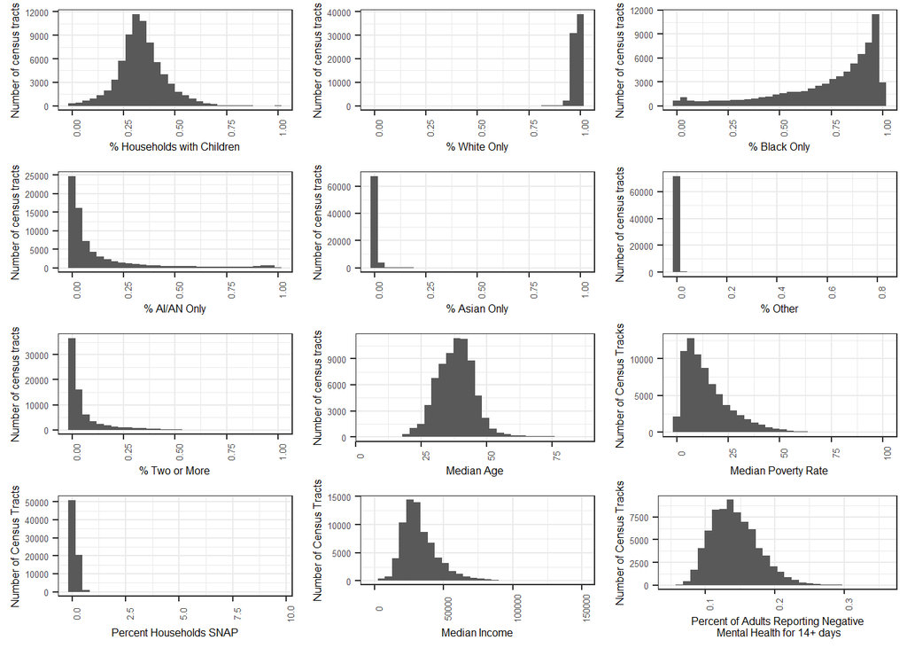

```r
pretty_children_hist <- children_hist +
  theme_bw() +
  scale_x_continuous(name = "% Households with Children") +
  scale_y_continuous(name = "Number of census tracts") +
  theme(text = element_text(size=6),axis.text.x = element_text(angle = 90))

pretty_RWhite_hist <- RWhite_hist +
  theme_bw() +
  scale_x_continuous(name = "% White Only") +
  scale_y_continuous(name = "Number of census tracts") +
  theme(text = element_text(size=6),axis.text.x = element_text(angle = 90))

pretty_RBlack_hist <- RBlack_hist +
  theme_bw() +
  scale_x_continuous(name = "% Black Only") +
  scale_y_continuous(name = "Number of census tracts") +
  theme(text = element_text(size=6),axis.text.x = element_text(angle = 90))

pretty_RAI_hist <- RAI_hist +
  theme_bw() +
  scale_x_continuous(name = "% AI/AN Only") +
  scale_y_continuous(name = "Number of census tracts") +
  theme(text = element_text(size=6),axis.text.x = element_text(angle = 90))

pretty_RAsian_hist <- RAsian_hist +
  theme_bw() +
  scale_x_continuous(name = "% Asian Only") +
  scale_y_continuous(name = "Number of census tracts") +
  theme(text = element_text(size=6),axis.text.x = element_text(angle = 90))

pretty_RNH_hist <- RNH_hist +
  theme_bw() +
  scale_x_continuous(name = "% Hawiian Only") +
  scale_y_continuous(name = "Number of census tracts") +
  theme(text = element_text(size=6),axis.text.x = element_text(angle = 90))

pretty_ROther_hist <- ROther_hist +
  theme_bw() +
  scale_x_continuous(name = "% Other") +
  scale_y_continuous(name = "Number of census tracts") +
  theme(text = element_text(size=6),axis.text.x = element_text(angle = 90))

pretty_RTwoPlus_hist <- RTwoPlus_hist +
  theme_bw() +
  scale_x_continuous(name = "% Two or More") +
  scale_y_continuous(name = "Number of census tracts") +
  theme(text = element_text(size=6),axis.text.x = element_text(angle = 90))

pretty_age_hist <- age_hist +
  theme_bw() +
  scale_x_continuous(name = "Median Age") +
  scale_y_continuous(name = "Number of census tracts") +
  theme(text = element_text(size=6),axis.text.x = element_text(angle = 90))

pretty_pov_hist <- pov_hist +
  theme_bw() +
  scale_x_continuous(name = "Median Poverty Rate") +
  scale_y_continuous(name = "Number of Census Tracks") +
  theme(text = element_text(size=6),axis.text.x = element_text(angle = 90))

pretty_SNAP_hist <- SNAP_hist +
  theme_bw() +
  scale_x_continuous(name = "Percent Households SNAP") +
  scale_y_continuous(name = "Number of Census Tracts") +
  theme(text = element_text(size=6),axis.text.x = element_text(angle = 90))

pretty_income_hist = income_hist +
  theme_bw() +
  scale_x_continuous(name = "Median Income") +
  scale_y_continuous(name = "Number of Census Tracts") +
  theme(text = element_text(size=6), axis.text.x = element_text(angle = 90))

pretty_MentalHealth_hist <- MentalHealth_hist +
  theme_bw() +
  scale_x_continuous(name = "Percent of Adults Reporting Negative\n Mental Health for 14+ days") +
  scale_y_continuous(name = "Number of Census Tracks") +
  theme(text = element_text(size=6),axis.text.x = element_text(angle = 90))

grid.arrange(pretty_children_hist, pretty_RWhite_hist, pretty_RBlack_hist, pretty_RAI_hist, pretty_RAsian_hist, pretty_ROther_hist, pretty_RTwoPlus_hist, pretty_age_hist, pretty_pov_hist, pretty_SNAP_hist, pretty_income_hist, pretty_MentalHealth_hist,
             ncol = 3)
```

## Categorical Variables

### Access to food options within 1 mile urban or 10 miles rural

```r
pct_access <- t.test(data$LA1and10 == "0")
pct_noaccess <-  t.test(data$LA1and10 == "1")
```

### Display Access to food options within 1 mile urban or 10 miles rural

```r
cat_summary_access <- tibble(`Access to Food` =
                              c("Access",
                                "No Access"),
                            `Sample proportion` =
                              c(pct_access$estimate * 100,
                                pct_noaccess$estimate *100),
                            `95-percent confidence - low` =
                              c(pct_access$conf.int[1] * 100,
                                pct_noaccess$conf.int[1] * 100),
                            `95-percent confidence - high` =
                              c(pct_access$conf.int[2] * 100,
                                pct_noaccess$conf.int[2] * 100))

kable(cat_summary_access, digits = 0)
```

| Access to Food | Sample proportion | 95-percent confidence - low | 95-percent confidence - high |
| --- | --- | --- | --- |
| Access | 62 | 62 | 62 |
| No Access | 38 | 38 | 38 |

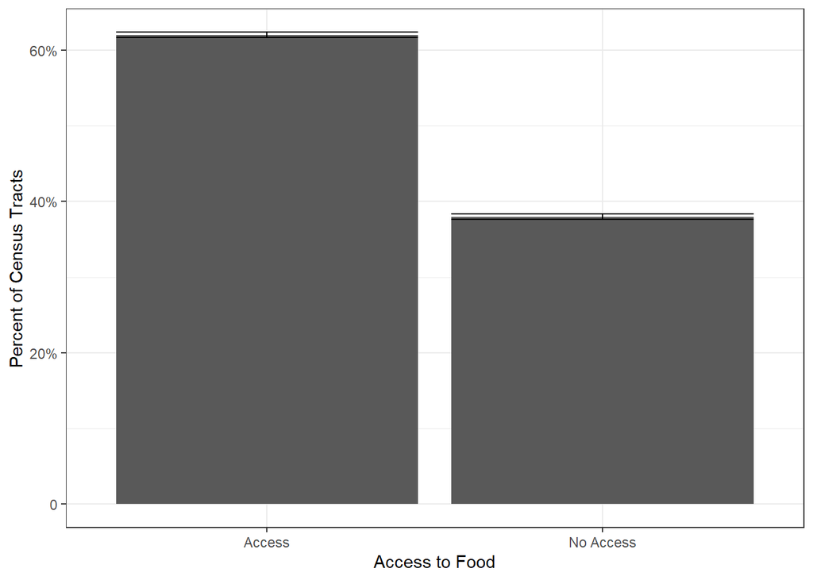

```r
ggplot(cat_summary_access) +
  geom_bar(aes(x = `Access to Food`,
               y = `Sample proportion`),
           stat = "identity") +
  geom_errorbar(aes(x = `Access to Food`,
               y = `Sample proportion`,
               ymin = `95-percent confidence - low`,
               ymax = `95-percent confidence - high`),
           stat = "identity") +
  scale_y_continuous(name = "Percent of Census Tracts",
                     breaks = c(0, 20, 40, 60, 80),
                     labels = c("0", "20%", "40%", "60%", "80%")) +
  theme_bw()
```

### Education

```r
pct_EdHS <- t.test(data$MaxEd == "High School")
pct_EdGED <- t.test(data$MaxEd == "GED")
pct_EdAssociates <- t.test(data$MaxEd == "Associates")
pct_EdBachelors <- t.test(data$MaxEd == "Bachelors")
pct_EdMasters <- t.test(data$MaxEd == "Masters")
pct_EdProfessional <- t.test(data$MaxEd == "Professional")
pct_EdDoctorate <- t.test(data$MaxEd == "Doctorate")
```

### Display Education

```r
cat_summary_Ed <- tibble(`Educational Attainment` =
                              c("High School",
                                "GED",
                                "Associates",
                                "Bachelors",
                                "Masters",
                                "Professional",
                                "Doctorate"),
                            `Sample proportion` =
                              c(pct_EdHS$estimate * 100,
                                pct_EdGED$estimate * 100,
                                pct_EdAssociates$estimate * 100,
                                pct_EdBachelors$estimate * 100,
                                pct_EdMasters$estimate * 100,
                                pct_EdProfessional$estimate * 100,
                                pct_EdDoctorate$estimate * 100),
                            `95-percent confidence - low` =
                              c(pct_EdHS$conf.int[1] * 100,
                                pct_EdGED$conf.int[1] * 100,
                                pct_EdAssociates$conf.int[1] * 100,
                                pct_EdBachelors$conf.int[1] * 100,
                                pct_EdMasters$conf.int[1] * 100,
                                pct_EdProfessional$conf.int[1] * 100,
                                pct_EdDoctorate$conf.int[1] * 100),
                            `95-percent confidence - high` =
                              c(pct_EdHS$conf.int[2] * 100,
                                pct_EdGED$conf.int[2] * 100,
                                pct_EdAssociates$conf.int[2] * 100,
                                pct_EdBachelors$conf.int[2] * 100,
                                pct_EdMasters$conf.int[2] * 100,
                                pct_EdProfessional$conf.int[2] * 100,
                                pct_EdDoctorate$conf.int[2] * 100))

kable(cat_summary_Ed, digits = 0)
```

| Educational Attainment | Sample proportion | 95-percent confidence - low | 95-percent confidence - high |
| --- | --- | --- | --- |
| High School | 64 | 63 | 64 |
| GED | 0 | 0 | 0 |
| Associates | 0 | 0 | 0 |
| Bachelors | 35 | 35 | 35 |
| Masters | 1 | 1 | 1 |
| Professional | 0 | 0 | 0 |
| Doctorate | 0 | 0 | 0 |

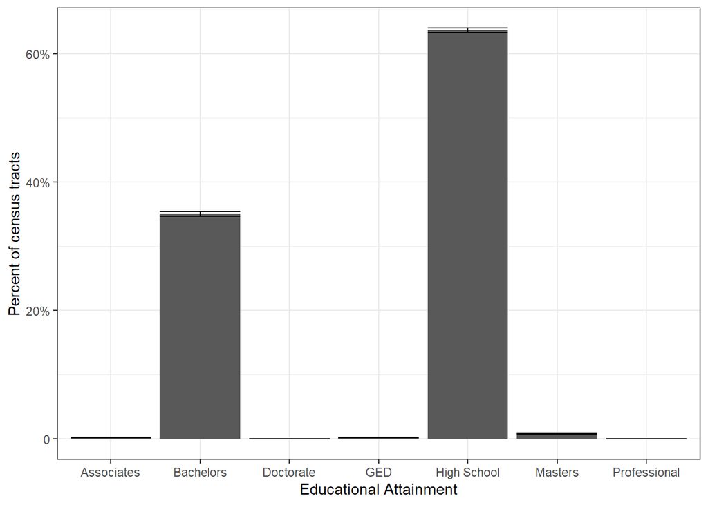

```r
ggplot(cat_summary_Ed) +
  geom_bar(aes(x = `Educational Attainment`,
               y = `Sample proportion`),
           stat = "identity") +
  geom_errorbar(aes(x = `Educational Attainment`,
               y = `Sample proportion`,
               ymin = `95-percent confidence - low`,
               ymax = `95-percent confidence - high`),
           stat = "identity") +
  scale_y_continuous(name = "Percent of census tracts",
                     breaks = c(0, 20, 40, 60, 80),
                     labels = c("0", "20%", "40%", "60%", "80%")) +
  theme_bw()
```

# Bivariate Analysis

The continuous variable we are testing as dependent is mental health.

## Continuous-Continuous Correlation Test

### Age

```r
cor.test(~ pct_PMH + MedAge, data = data)
```

```
##
##  Pearson's product-moment correlation
##
## data:  pct_PMH and MedAge
## t = -150.28, df = 72130, p-value < 2.2e-16
## alternative hypothesis: true correlation is not equal to 0
## 95 percent confidence interval:
##  -0.4938497 -0.4827344
## sample estimates:
##        cor
## -0.4883118
```

```r
age_model <- lm(pct_PMH ~ MedAge, data = data)
```

The correlation for mental health and median age is -0.4883118 and the 95% confidence interval is below zero. We can say with 95% confidence that an increase in median age correlates with an decrease in poor mental health outcomes.

### Median Income

```r
cor.test(~ pct_PMH + MedIncomeE, data = data)
```

```
##
##  Pearson's product-moment correlation
##
## data:  pct_PMH and MedIncomeE
## t = -314.53, df = 72093, p-value < 2.2e-16
## alternative hypothesis: true correlation is not equal to 0
## 95 percent confidence interval:
##  -0.7636283 -0.7574741
## sample estimates:
##        cor
## -0.7605683
```

```r
MedIncome_model <- lm(pct_PMH ~ MedIncomeE, data = data)
```

The correlation for mental health and median income is -0.7605683 and the 95% confidence interval is below zero. This indicates we can say with 95% that there is a negative correlation between mental health and median incom. As the median income increases within a census track, the percent of adults reporting poor mental health decreases.

### Poverty Rate

```r
cor.test(~ pct_PMH + PovertyRate, data = data)
```

```
##
##  Pearson's product-moment correlation
##
## data:  pct_PMH and PovertyRate
## t = 374.78, df = 72328, p-value < 2.2e-16
## alternative hypothesis: true correlation is not equal to 0
## 95 percent confidence interval:
##  0.8099702 0.8149246
## sample estimates:
##       cor
## 0.8124621
```

```r
MedIncome_model <- lm(pct_PMH ~ PovertyRate, data = data)
```

The correlation for mental health and poverty rate is 0.8124621 and the 95% confidence interval is above zero. This indicates we can say with 95% that there is a correlation between mental health and a census track’s poverty rate. As the percent of poverty increases, so does the percent of adults reporting poor mental health.

### Percent of Households using SNAP

```r
cor.test(~ pct_PMH + pct_SNAP, data = data)
```

```
##
##  Pearson's product-moment correlation
##
## data:  pct_PMH and pct_SNAP
## t = 257.78, df = 72234, p-value < 2.2e-16
## alternative hypothesis: true correlation is not equal to 0
## 95 percent confidence interval:
##  0.6883921 0.6959888
## sample estimates:
##       cor
## 0.6922096
```

```r
SNAP_model <- lm(pct_PMH ~ pct_SNAP, data = data)
```

The correlation for mental health and percent of households using SNAP is 0.6922096, and the 95% confidence interval is above zero. We can say with 95% confidence that an increase in households using SNAP correlates with an increase in poor mental health outcomes.

### Percent of Households with Children

```r
cor.test(~ pct_PMH + pct_UnitsWChildren, data = data)
```

```
##
##  Pearson's product-moment correlation
##
## data:  pct_PMH and pct_UnitsWChildren
## t = 48.223, df = 72036, p-value < 2.2e-16
## alternative hypothesis: true correlation is not equal to 0
## 95 percent confidence interval:
##  0.1697550 0.1839032
## sample estimates:
##       cor
## 0.1768382
```

```r
UnitsWChildren_model <- lm(pct_PMH ~ pct_UnitsWChildren, data = data)
```

The correlation for poor mental health and percent of homes with children is 0.1768382 and the 95% confidence interval is all positive numbers, which means we can say with 95% certainty that there is an increase in percent of people with poor mental health days as the percent of homes with children in a census tract increases. The p-value is 2.2e-16 (the lowest number R will provide), which means it is very unlikely this pattern would appear if the variables were not correlated.

### Race

```r
RWhite_corr <- cor.test(~ pct_PMH + pct_RWhite, data = data)
RBlack_corr <- cor.test(~ pct_PMH + pct_RBlack, data = data)
RAI_corr <- cor.test(~ pct_PMH + pct_RAI, data = data)
RAsian_corr <- cor.test(~ pct_PMH + pct_RAsian, data = data)
RNH_corr <- cor.test(~ pct_PMH + pct_RNH, data = data)
ROther_corr <- cor.test(~ pct_PMH + pct_ROther, data = data)
RTwoPlus_corr <- cor.test(~ pct_PMH + pct_RTwoPlus, data = data)

Race_corr_summary <- tibble(`Race` =
                              c("White",
                                "Black",
                                "AI/AN",
                                "Asian",
                                "Hawiian",
                                "Other",
                                "Two or More"),
                            `Correlation Estimate` =
                              c(RWhite_corr$estimate,
                                RBlack_corr$estimate,
                                RAI_corr$estimate,
                                RAsian_corr$estimate,
                                RNH_corr$estimate,
                                ROther_corr$estimate,
                                RTwoPlus_corr$estimate),
                            `95% Confidence Interval, low` =
                               c(RWhite_corr$conf.int[1],
                                RBlack_corr$conf.int[1],
                                RAI_corr$conf.int[1],
                                RAsian_corr$conf.int[1],
                                RNH_corr$conf.int[1],
                                ROther_corr$conf.int[1],
                                RTwoPlus_corr$conf.int[1]),
                            `95% Confidence Interval, high` =
                               c(RWhite_corr$conf.int[2],
                                RBlack_corr$conf.int[2],
                                RAI_corr$conf.int[2],
                                RAsian_corr$conf.int[2],
                                RNH_corr$conf.int[2],
                                ROther_corr$conf.int[2],
                                RTwoPlus_corr$conf.int[2]),                                                        `p-value` =
                                c(RWhite_corr$p.value,
                                  RBlack_corr$p.value,
                                  RAI_corr$p.value,
                                  RAsian_corr$p.value,
                                  RNH_corr$p.value,
                                  ROther_corr$p.value,
                                  RTwoPlus_corr$p.value))

kable(Race_corr_summary)
```

| Race | Correlation Estimate | 95% Confidence Interval, low | 95% Confidence Interval, high | p-value |
| --- | --- | --- | --- | --- |
| White | -0.0859485 | -0.0931877 | -0.0787002 | 0.0000000 |
| Black | -0.3472142 | -0.3536158 | -0.3407800 | 0.0000000 |
| AI/AN | 0.3911171 | 0.3849181 | 0.3972809 | 0.0000000 |
| Asian | 0.1627120 | 0.1555991 | 0.1698081 | 0.0000000 |
| Hawiian | -0.2889030 | -0.2955775 | -0.2822003 | 0.0000000 |
| Other | -0.0122452 | -0.0195412 | -0.0049480 | 0.0010061 |
| Two or More | 0.2152150 | 0.2082443 | 0.2221637 | 0.0000000 |

```r
RWhite_model <- lm(pct_PMH ~ pct_RWhite, data = data)
RBlack_model <- lm(pct_PMH ~ pct_RBlack, data = data)
RAI_model <- lm(pct_PMH ~ pct_RAI, data = data)
RAsian_model <- lm(pct_PMH ~ pct_RAsian, data = data)
RNH_model <- lm(pct_PMH ~ pct_RNH, data = data)
ROther_model <- lm(pct_PMH ~ pct_ROther, data = data)
RTwoPlus_model <- lm(pct_PMH ~ pct_RTwoPlus, data = data)
```

The results of correlation tests between the percent of poor mental health days and the racial demographic data are summarized in this table. All p values are low enough to be 95% confident in the correlation of racial demographics and mental health reporting. The confidence interval values for each variable are either both negative or both positive, so the correlation estimate cannot be zero within 95% confidence. Correlation estimates are positive for American Indian & Alaska Native, Asian, and Two or More, meaning as the percentages of these populations increase within a census tract the percentage of individuals experiencing poor mental health days is expected to increase. Correlation estimates are negative for White, Black, Native Hawaiian, and Other, meaning poor mental health days decrease as the percentage of these populations increase. It is worth noting here that the Two or More and Other categories are broad enough to provide little value to this analysis, but we have included them out of curiosity.

## Continuous-Categorical Difference in Means Test

### Access to Food Options

```r
FoodAccess_model <- lm(pct_PMH ~ LA1and10, data = data)
summary(FoodAccess_model)
```

```
##
## Call:
## lm(formula = pct_PMH ~ LA1and10, data = data)
##
## Residuals:
##       Min        1Q    Median        3Q       Max
## -0.088892 -0.024892 -0.003565  0.020435  0.210108
##
## Coefficients:
##               Estimate Std. Error t value Pr(>|t|)
## (Intercept)  0.1448920  0.0001603  904.10   <2e-16 ***
## LA1and10    -0.0063272  0.0002600  -24.33   <2e-16 ***
## ---
## Signif. codes:  0 '***' 0.001 '**' 0.01 '*' 0.05 '.' 0.1 ' ' 1
##
## Residual standard error: 0.03394 on 72328 degrees of freedom
##   (196 observations deleted due to missingness)
## Multiple R-squared:  0.00812,    Adjusted R-squared:  0.008106
## F-statistic: 592.1 on 1 and 72328 DF,  p-value: < 2.2e-16
```

*The USDA defines urban census blocks within 1 mile of food and rural census blocks within 10 miles of food as having food access.

### Education

```r
data <- data %>%
  mutate(MaxEd = as.factor(MaxEd)) %>%
  mutate(MaxEd = relevel(MaxEd, "High School"))

MaxEd_model <- lm(pct_PMH ~ MaxEd, data)

summary(MaxEd_model)
```

```
##
## Call:
## lm(formula = pct_PMH ~ MaxEd, data = data)
##
## Residuals:
##       Min        1Q    Median        3Q       Max
## -0.091714 -0.018839 -0.003714  0.014286  0.212161
##
## Coefficients:
##                     Estimate Std. Error  t value Pr(>|t|)
## (Intercept)        0.1567140  0.0001314 1192.858  < 2e-16 ***
## MaxEdAssociates    0.0078871  0.0021445    3.678 0.000235 ***
## MaxEdBachelors    -0.0398752  0.0002205 -180.842  < 2e-16 ***
## MaxEdDoctorate    -0.0363140  0.0089038   -4.078 4.54e-05 ***
## MaxEdGED           0.0160172  0.0022296    7.184 6.84e-13 ***
## MaxEdMasters      -0.0371942  0.0011754  -31.645  < 2e-16 ***
## MaxEdProfessional -0.0253807  0.0093854   -2.704 0.006847 **
## ---
## Signif. codes:  0 '***' 0.001 '**' 0.01 '*' 0.05 '.' 0.1 ' ' 1
##
## Residual standard error: 0.02815 on 72123 degrees of freedom
##   (396 observations deleted due to missingness)
## Multiple R-squared:  0.3165, Adjusted R-squared:  0.3164
## F-statistic:  5565 on 6 and 72123 DF,  p-value: < 2.2e-16
```

The most common educational attainment among the census tracts is high school, so this analysis uses high school as the baseline of comparison for the other categorical values. All variables have low p-values, so the confidence intervals are 95% for each. The categories of high school, associates, and GED have positive correlation estimates, census tracts in which these are the most common educational attainment are likely to have higher rates of poor mental health. Conversely, bachelors, masters, professional, and doctorate degrees have negative correlation estimates, so poor mental health rates are expected to decrease in tracts in which these are the most commonly attained levels of education.

# Multivariate Regression

```r
full_model <- lm(pct_PMH ~ pct_SNAP + PovertyRate + MedIncomeE + MedAge + pct_UnitsWChildren + pct_RWhite + pct_RBlack + pct_RAI + pct_RAsian + pct_RNH + pct_RTwoPlus+ LA1and10 + MaxEd, data)

summary(full_model)
```

```
##
## Call:
## lm(formula = pct_PMH ~ pct_SNAP + PovertyRate + MedIncomeE +
##     MedAge + pct_UnitsWChildren + pct_RWhite + pct_RBlack + pct_RAI +
##     pct_RAsian + pct_RNH + pct_RTwoPlus + LA1and10 + MaxEd, data = data)
##
## Residuals:
##       Min        1Q    Median        3Q       Max
## -0.178629 -0.008122  0.000261  0.008239  0.128458
##
## Coefficients:
##                      Estimate Std. Error  t value Pr(>|t|)
## (Intercept)         2.112e-01  4.154e-03   50.843  < 2e-16 ***
## pct_SNAP            1.775e-02  6.397e-04   27.751  < 2e-16 ***
## PovertyRate         1.386e-03  7.620e-06  181.923  < 2e-16 ***
## MedIncomeE         -6.246e-07  5.766e-09 -108.326  < 2e-16 ***
## MedAge             -9.636e-04  9.768e-06  -98.647  < 2e-16 ***
## pct_UnitsWChildren  2.198e-02  6.229e-04   35.287  < 2e-16 ***
## pct_RWhite         -6.413e-02  1.038e-02   -6.176 6.61e-10 ***
## pct_RBlack          3.217e-02  7.314e-03    4.398 1.09e-05 ***
## pct_RAI             2.668e-02  7.301e-03    3.654 0.000258 ***
## pct_RAsian          5.773e-02  7.305e-03    7.902 2.78e-15 ***
## pct_RNH            -2.243e-02  7.350e-03   -3.052 0.002276 **
## pct_RTwoPlus       -2.564e-02  7.144e-03   -3.589 0.000332 ***
## LA1and10           -7.844e-04  1.077e-04   -7.284 3.27e-13 ***
## MaxEdAssociates    -2.260e-03  1.051e-03   -2.151 0.031512 *
## MaxEdBachelors     -1.197e-02  1.404e-04  -85.260  < 2e-16 ***
## MaxEdDoctorate     -1.799e-02  4.266e-03   -4.217 2.48e-05 ***
## MaxEdGED            5.809e-03  1.237e-03    4.697 2.64e-06 ***
## MaxEdMasters       -1.155e-02  5.866e-04  -19.697  < 2e-16 ***
## MaxEdProfessional   5.031e-03  4.767e-03    1.055 0.291263
## ---
## Signif. codes:  0 '***' 0.001 '**' 0.01 '*' 0.05 '.' 0.1 ' ' 1
##
## Residual standard error: 0.01347 on 71971 degrees of freedom
##   (536 observations deleted due to missingness)
## Multiple R-squared:  0.8431, Adjusted R-squared:  0.843
## F-statistic: 2.148e+04 on 18 and 71971 DF,  p-value: < 2.2e-16
```

## Overview

We ran a multivariate linear regression of the independent variables in this analysis to examine their effects on the percent of people experiencing fourteen or more poor mental health days per year, across the United States at the scale of the census tract. The independent variables included are percent of population utilizing SNAP benefits, poverty rate, median income, median age, percent of households with children, if the census tract has high access to food (based on 1 mile for urban areas and 10 miles for rural areas), the most common highest educational attainment within the census tract, and the percent of population that identify as one of the following racial categories: white, Black, American Indian/Alaska Native, Asian, Native Hawiian, or two or more. The racial category of “other” was excluded from the regression to avoid a singularity, since all of the racial categories would add up to 100%. This would yield multicollinearity such that the regression would not be completed for all racial demographic variables. We chose to exclude “other” since it revealed the least information, as it is the broadest grouping within this part of the census.

The model’s R squared value is 0.843, so this combination of independent variables explains 84% of the variation in percent of population experiencing poor mental health for more than 14 days. This is a high R squared value, which could suggest that poor mental health is well predicted by the independent variables we included in this regression. Other independent variables to consider including to explain the remaining variation could be homeownership rates, physical health outcomes, and health care access.

## Positive Correlation:

The following summary assumes that all other variables are held constant, except for the independent variable in question:

A 1% increase in SNAP utilization is associated with a 0.0177% increase in the percent of adults experiencing poor mental health for more than 14 days. SNAP is a food stamp program that assists low-income individuals, so higher SNAP utilization may indicate lower financial security resulting in poor mental health.

A 1% increase in Poverty Rate is associated with a 0.001386% increase in the percent of adults experiencing poor mental health for more than 14 days. This increase in Poverty Rate indicates lower financial security that also results in poor mental health.

A 1% increase in Units with Children is associated with a 0.02198% increase in the percent of adults experiencing poor mental health for more than 14 days. Units with children may present lower financial security given the additional mouths to feed and children to care for, resulting in poor mental health.

A 1% increase in a census tract’s Black population is associated with a 0.03217% increase in the percent of adults experiencing poor mental health for more than 14 days. A 1% increase in a census tract’s American Indian population is associated with a 0.02668% increase in the percent of adults experiencing poor mental health for more than 14 days. A 1% increase in a census tract’s Asian population is associated with a 0.05773% increase in the percent of adults experiencing poor mental health for more than 14 days. Racial discrimination and systemic racism towards non-white individuals can contribute to higher levels of hypertension and stress, so this logically results in more adults experiencing poor mental health.

## Negative Correlation:

# Transformations

```r
coeff_names <- c("Constant" = "(Intercept)",
                 "SNAP Utilization" = "pct_SNAP",
                 "Poverty Rate" = "PovertyRate",
                 "Median Age" = "MedAge",
                 "Median Income" = "MedIncomeE",
                 "Doubling Median Income" = "log2_MedIncome",
                 "% Units with Children" = "pct_UnitsWChildren",
                 "% White" = "pct_RWhite",
                 "% Black" = "pct_RBlack",
                 "% AI" = "pct_RAI",
                 "% Asian" = "pct_RAsian",
                 "% NH" = "pct_RNH",
                 "% Two Plus Races" = "pct_RTwoPlus",
                 "Access to Food (1 Mile Urban and 10 Miles Rural)" = "LA1and10")

scaled_data <- data %>%
  mutate(pct_SNAP = pct_SNAP / 100,
         PovertyRate = PovertyRate / 100,
         MedIncomeE = MedIncomeE / 1000000,
         MedAge = MedAge / 10,
         pct_UnitsWChildren = pct_UnitsWChildren / 100,
         pct_RWhite = pct_RWhite / 100,
         pct_RBlack = pct_RBlack / 100,
         pct_RAI = pct_RAI / 100,
         pct_RAsian = pct_RAsian / 100,
         pct_RNH = pct_RNH / 100,
         pct_RTwoPlus = pct_RTwoPlus / 100)

scaled_model <- lm(pct_PMH ~ pct_SNAP + PovertyRate + MedIncomeE + MedAge + pct_UnitsWChildren + pct_RWhite + pct_RBlack + pct_RAI + pct_RAsian + pct_RNH + pct_RTwoPlus+ LA1and10 + MaxEd, scaled_data)

scaled_data_medIncome_log <- scaled_data %>%
  mutate(log2_MedIncome = log(MedIncomeE, base = 2))


scaled_MedIncome_model_log <- lm(pct_PMH ~ pct_SNAP + PovertyRate + log2_MedIncome + MedAge + pct_UnitsWChildren + pct_RWhite + pct_RBlack + pct_RAI + pct_RAsian + pct_RNH + pct_RTwoPlus+ LA1and10 + MaxEd, data = scaled_data_medIncome_log)


export_summs(full_model, scaled_model, scaled_MedIncome_model_log,
             error_format = "(p = {p.value})",
             error_pos = "same",
             model.names = c("Initial",
                             "Scaled Data",
                             "Median Income Logged"),
             coefs = coeff_names)
```

|  | Initial | Scaled Data | Median Income Logged |
| --- | --- | --- | --- |
| Constant | 0.21 *** (p = 0.00) | 0.21 *** (p = 0.00) | 0.11 *** (p = 0.00) |
| SNAP Utilization | 0.02 *** (p = 0.00) | 1.78 *** (p = 0.00) | 1.83 *** (p = 0.00) |
| Poverty Rate | 0.00 *** (p = 0.00) | 0.14 *** (p = 0.00) | 0.12 *** (p = 0.00) |
| Median Age | -0.00 *** (p = 0.00) | -0.01 *** (p = 0.00) | -0.01 *** (p = 0.00) |
| Median Income | -0.00 *** (p = 0.00) | -0.62 *** (p = 0.00) |  |
| Doubling Median Income |  |  | -0.02 *** (p = 0.00) |
| % Units with Children | 0.02 *** (p = 0.00) | 2.20 *** (p = 0.00) | 2.39 *** (p = 0.00) |
| % White | -0.06 *** (p = 0.00) | -6.41 *** (p = 0.00) | -7.50 *** (p = 0.00) |
| % Black | 0.03 *** (p = 0.00) | 3.22 *** (p = 0.00) | 3.21 *** (p = 0.00) |
| % AI | 0.03 *** (p = 0.00) | 2.67 *** (p = 0.00) | 2.71 *** (p = 0.00) |
| % Asian | 0.06 *** (p = 0.00) | 5.77 *** (p = 0.00) | 5.81 *** (p = 0.00) |
| % NH | -0.02 ** (p = 0.00) | -2.24 ** (p = 0.00) | -2.52 *** (p = 0.00) |
| % Two Plus Races | -0.03 *** (p = 0.00) | -2.56 *** (p = 0.00) | -2.32 *** (p = 0.00) |
| Access to Food (1 Mile Urban and 10 Miles Rural) | -0.00 *** (p = 0.00) | -0.00 *** (p = 0.00) | -0.00 *** (p = 0.00) |
| N | 71990 | 71990 | 71990 |
| R2 | 0.84 | 0.84 | 0.85 |
| *** p < 0.001; ** p < 0.01; * p < 0.05. |  |  |  |

We first scaled the continuous variables to represent whole numbers rather than percentages and to represent age by decades and median income by units of one million. This transformed the coefficient to be more legible in the context of the tables.

The second transformation took the base 2 log of median income, which increased the R-squared value from 0.84 to 0.85. This nominal difference is a slightly better fit for the model.

# Interactions

## pct_SNAP and MaxEd

```r
coeff_names_interaction <- c("Constant" = "(Intercept)",
                 "SNAP Utilization" = "pct_SNAP",
                 "Poverty Rate" = "PovertyRate",
                 "Median Age" = "MedAge",
                 "Median Income" = "MedIncomeE",
                 "Doubling Median Income" = "log2_MedIncome",
                 "% Units with Children" = "pct_UnitsWChildren",
                 "% White" = "pct_RWhite",
                 "% Black" = "pct_RBlack",
                 "% AI" = "pct_RAI",
                 "% Asian" = "pct_RAsian",
                 "% NH" = "pct_RNH",
                 "% Two Plus Races" = "pct_RTwoPlus",
                 "Access to Food (1 Mile Urban and 10 Miles Rural)" = "LA1and10")


interaction_SNAP_ED_model <- lm(pct_PMH ~ pct_SNAP + PovertyRate + log2_MedIncome + MedAge + pct_UnitsWChildren + pct_RWhite + pct_RBlack + pct_RAI + pct_RAsian + pct_RNH + pct_RTwoPlus+ LA1and10 + MaxEd + pct_SNAP*MaxEd, data = scaled_data_medIncome_log)

export_summs(scaled_MedIncome_model_log, interaction_SNAP_ED_model,
             error_format = "(p = {p.value})",
             error_pos = "same",
             model.names = c("Median Income Logged",
                             "SNAP and Ed Interaction"))
```

|  | Median Income Logged | SNAP and Ed Interaction |
| --- | --- | --- |
| (Intercept) | 0.11 *** (p = 0.00) | 0.11 *** (p = 0.00) |
| pct_SNAP | 1.83 *** (p = 0.00) | 1.83 *** (p = 0.00) |
| PovertyRate | 0.12 *** (p = 0.00) | 0.12 *** (p = 0.00) |
| log2_MedIncome | -0.02 *** (p = 0.00) | -0.02 *** (p = 0.00) |
| MedAge | -0.01 *** (p = 0.00) | -0.01 *** (p = 0.00) |
| pct_UnitsWChildren | 2.39 *** (p = 0.00) | 2.38 *** (p = 0.00) |
| pct_RWhite | -7.50 *** (p = 0.00) | -7.49 *** (p = 0.00) |
| pct_RBlack | 3.21 *** (p = 0.00) | 3.21 *** (p = 0.00) |
| pct_RAI | 2.71 *** (p = 0.00) | 2.70 *** (p = 0.00) |
| pct_RAsian | 5.81 *** (p = 0.00) | 5.80 *** (p = 0.00) |
| pct_RNH | -2.52 *** (p = 0.00) | -2.53 *** (p = 0.00) |
| pct_RTwoPlus | -2.32 *** (p = 0.00) | -2.32 *** (p = 0.00) |
| LA1and10 | -0.00 *** (p = 0.00) | -0.00 *** (p = 0.00) |
| MaxEdAssociates | -0.01 *** (p = 0.00) | -0.01 *** (p = 0.00) |
| MaxEdBachelors | -0.01 *** (p = 0.00) | -0.01 *** (p = 0.00) |
| MaxEdDoctorate | -0.02 *** (p = 0.00) | -0.02 *** (p = 0.00) |
| MaxEdGED | -0.01 *** (p = 0.00) | -0.01 *** (p = 0.00) |
| MaxEdMasters | -0.02 *** (p = 0.00) | -0.02 *** (p = 0.00) |
| MaxEdProfessional | -0.01 * (p = 0.02) | -0.01 (p = 0.20) |
| pct_SNAP:MaxEdAssociates |  | -0.28 (p = 0.73) |
| pct_SNAP:MaxEdBachelors |  | -0.08 (p = 0.55) |
| pct_SNAP:MaxEdDoctorate |  | -29.51 (p = 0.07) |
| pct_SNAP:MaxEdGED |  | 2.28 *** (p = 0.00) |
| pct_SNAP:MaxEdMasters |  | -0.38 (p = 0.50) |
| pct_SNAP:MaxEdProfessional |  | -14.04 (p = 0.19) |
| N | 71990 | 71990 |
| R2 | 0.85 | 0.85 |
| *** p < 0.001; ** p < 0.01; * p < 0.05. |  |  |

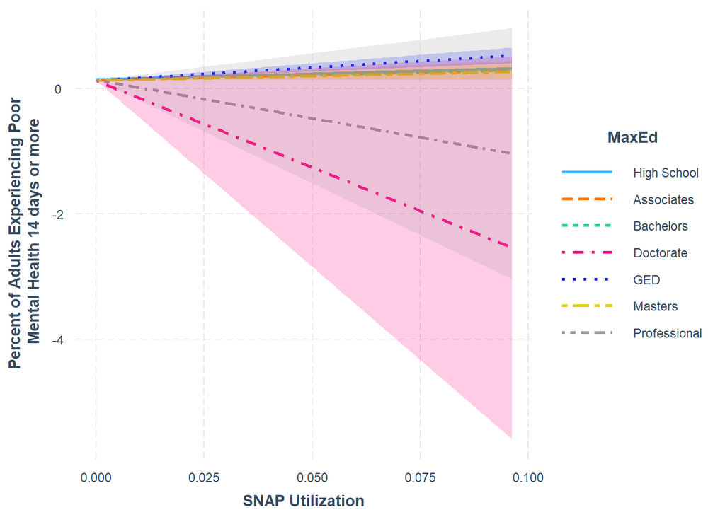

```r
interact_plot(interaction_SNAP_ED_model, pred = pct_SNAP, modx = MaxEd,
              interval = TRUE) +
  scale_x_continuous(name = "SNAP Utilization") +
  scale_y_continuous(name = "Percent of Adults Experiencing Poor\n Mental Health 14 days or more")
```

The model fit did not change. The interaction between SNAP utilization and maximum educational attainment is only significant for GED. The coefficient is positive as is the coefficient for pct_SNAP indicating the relationship between SNAP utilization and poor mental health days is stronger in census tracts that have GED as the maximum educational attainment.

## pct_SNAP and pct_UnitsWChildren

```r
interaction_SNAP_Child_model <- lm(pct_PMH ~ pct_SNAP + PovertyRate + log2_MedIncome + MedAge + pct_UnitsWChildren + pct_RWhite + pct_RBlack + pct_RAI + pct_RAsian + pct_RNH + pct_RTwoPlus+ LA1and10 + MaxEd + pct_SNAP*pct_UnitsWChildren, data = scaled_data_medIncome_log)

export_summs(scaled_MedIncome_model_log, interaction_SNAP_Child_model,
             error_format = "(p = {p.value})",
             error_pos = "same",
             model.names = c("Median Income Logged",
                             "SNAP and Children Interaction"))
```

|  | Median Income Logged | SNAP and Children Interaction |
| --- | --- | --- |
| (Intercept) | 0.11 *** (p = 0.00) | 0.11 *** (p = 0.00) |
| pct_SNAP | 1.83 *** (p = 0.00) | 2.19 *** (p = 0.00) |
| PovertyRate | 0.12 *** (p = 0.00) | 0.12 *** (p = 0.00) |
| log2_MedIncome | -0.02 *** (p = 0.00) | -0.02 *** (p = 0.00) |
| MedAge | -0.01 *** (p = 0.00) | -0.01 *** (p = 0.00) |
| pct_UnitsWChildren | 2.39 *** (p = 0.00) | 2.53 *** (p = 0.00) |
| pct_RWhite | -7.50 *** (p = 0.00) | -7.30 *** (p = 0.00) |
| pct_RBlack | 3.21 *** (p = 0.00) | 3.08 *** (p = 0.00) |
| pct_RAI | 2.71 *** (p = 0.00) | 2.57 *** (p = 0.00) |
| pct_RAsian | 5.81 *** (p = 0.00) | 5.69 *** (p = 0.00) |
| pct_RNH | -2.52 *** (p = 0.00) | -2.67 *** (p = 0.00) |
| pct_RTwoPlus | -2.32 *** (p = 0.00) | -2.39 *** (p = 0.00) |
| LA1and10 | -0.00 *** (p = 0.00) | -0.00 *** (p = 0.00) |
| MaxEdAssociates | -0.01 *** (p = 0.00) | -0.01 *** (p = 0.00) |
| MaxEdBachelors | -0.01 *** (p = 0.00) | -0.01 *** (p = 0.00) |
| MaxEdDoctorate | -0.02 *** (p = 0.00) | -0.02 *** (p = 0.00) |
| MaxEdGED | -0.01 *** (p = 0.00) | -0.01 *** (p = 0.00) |
| MaxEdMasters | -0.02 *** (p = 0.00) | -0.02 *** (p = 0.00) |
| MaxEdProfessional | -0.01 * (p = 0.02) | -0.01 * (p = 0.02) |
| pct_SNAP:pct_UnitsWChildren |  | -111.06 *** (p = 0.00) |
| N | 71990 | 71990 |
| R2 | 0.85 | 0.85 |
| *** p < 0.001; ** p < 0.01; * p < 0.05. |  |  |

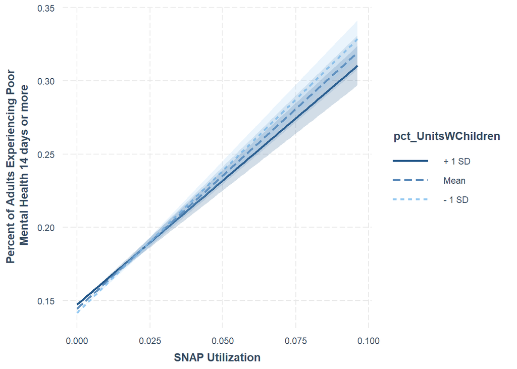

```r
interact_plot(interaction_SNAP_Child_model, pred = pct_SNAP, modx = pct_UnitsWChildren,
              interval = TRUE) +
  scale_x_continuous(name = "SNAP Utilization") +
  scale_y_continuous(name = "Percent of Adults Experiencing Poor\n Mental Health 14 days or more")
```

## median income and access to food within 1 mile urban and 10 mile rural

```r
coeff_names_interaction <- c("Constant" = "(Intercept)",
                 "SNAP Utilization" = "pct_SNAP",
                 "Poverty Rate" = "PovertyRate",
                 "Median Age" = "MedAge",
                 "Median Income" = "MedIncomeE",
                 "Doubling Median Income" = "log2_MedIncome",
                 "% Units with Children" = "pct_UnitsWChildren",
                 "% White" = "pct_RWhite",
                 "% Black" = "pct_RBlack",
                 "% AI" = "pct_RAI",
                 "% Asian" = "pct_RAsian",
                 "% NH" = "pct_RNH",
                 "% Two Plus Races" = "pct_RTwoPlus",
                 "Access to Food (1 Mile Urban and 10 Miles Rural)" = "LA1and10")


interaction_income_access_model <- lm(pct_PMH ~ pct_SNAP + PovertyRate + log2_MedIncome + MedAge + pct_UnitsWChildren + pct_RWhite + pct_RBlack + pct_RAI + pct_RAsian + pct_RNH + pct_RTwoPlus+ LA1and10 + MaxEd + log2_MedIncome*LA1and10, data = scaled_data_medIncome_log)

export_summs(scaled_MedIncome_model_log, interaction_income_access_model,
             error_format = "(p = {p.value})",
             error_pos = "same",
             model.names = c("Median Income Logged",
                             "Income and Access Interaction"))
```

|  | Median Income Logged | Income and Access Interaction |
| --- | --- | --- |
| (Intercept) | 0.11 *** (p = 0.00) | 0.11 *** (p = 0.00) |
| pct_SNAP | 1.83 *** (p = 0.00) | 1.83 *** (p = 0.00) |
| PovertyRate | 0.12 *** (p = 0.00) | 0.12 *** (p = 0.00) |
| log2_MedIncome | -0.02 *** (p = 0.00) | -0.02 *** (p = 0.00) |
| MedAge | -0.01 *** (p = 0.00) | -0.01 *** (p = 0.00) |
| pct_UnitsWChildren | 2.39 *** (p = 0.00) | 2.36 *** (p = 0.00) |
| pct_RWhite | -7.50 *** (p = 0.00) | -7.48 *** (p = 0.00) |
| pct_RBlack | 3.21 *** (p = 0.00) | 3.19 *** (p = 0.00) |
| pct_RAI | 2.71 *** (p = 0.00) | 2.69 *** (p = 0.00) |
| pct_RAsian | 5.81 *** (p = 0.00) | 5.81 *** (p = 0.00) |
| pct_RNH | -2.52 *** (p = 0.00) | -2.54 *** (p = 0.00) |
| pct_RTwoPlus | -2.32 *** (p = 0.00) | -2.33 *** (p = 0.00) |
| LA1and10 | -0.00 *** (p = 0.00) | 0.00 (p = 0.11) |
| MaxEdAssociates | -0.01 *** (p = 0.00) | -0.01 *** (p = 0.00) |
| MaxEdBachelors | -0.01 *** (p = 0.00) | -0.01 *** (p = 0.00) |
| MaxEdDoctorate | -0.02 *** (p = 0.00) | -0.02 *** (p = 0.00) |
| MaxEdGED | -0.01 *** (p = 0.00) | -0.01 *** (p = 0.00) |
| MaxEdMasters | -0.02 *** (p = 0.00) | -0.02 *** (p = 0.00) |
| MaxEdProfessional | -0.01 * (p = 0.02) | -0.01 * (p = 0.02) |
| log2_MedIncome:LA1and10 |  | 0.00 ** (p = 0.01) |
| N | 71990 | 71990 |
| R2 | 0.85 | 0.85 |
| *** p < 0.001; ** p < 0.01; * p < 0.05. |  |  |

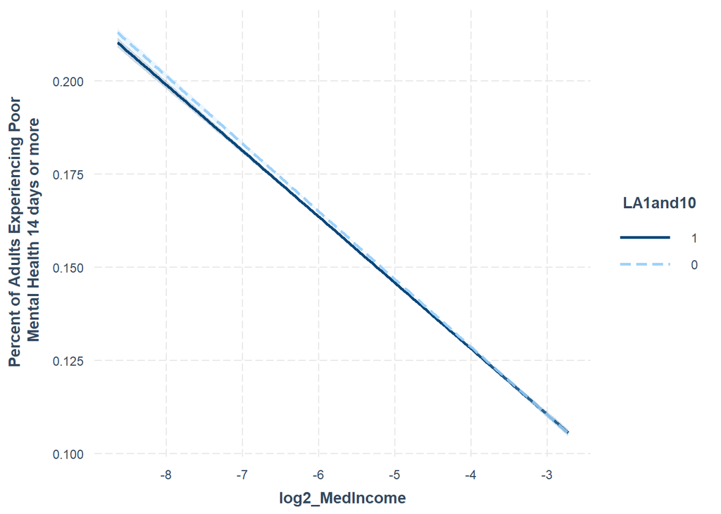

```r
interact_plot(interaction_income_access_model, pred = log2_MedIncome, modx = LA1and10,
              interval = TRUE) +
  scale_x_continuous(name = "log2_MedIncome") +
  scale_y_continuous(name = "Percent of Adults Experiencing Poor\n Mental Health 14 days or more")
```

## pct_SNAP and access to food within 1 mile urban and 10 mile rural

```r
coeff_names_interaction <- c("Constant" = "(Intercept)",
                 "SNAP Utilization" = "pct_SNAP",
                 "Poverty Rate" = "PovertyRate",
                 "Median Age" = "MedAge",
                 "Median Income" = "MedIncomeE",
                 "Doubling Median Income" = "log2_MedIncome",
                 "% Units with Children" = "pct_UnitsWChildren",
                 "% White" = "pct_RWhite",
                 "% Black" = "pct_RBlack",
                 "% AI" = "pct_RAI",
                 "% Asian" = "pct_RAsian",
                 "% NH" = "pct_RNH",
                 "% Two Plus Races" = "pct_RTwoPlus",
                 "Access to Food (1 Mile Urban and 10 Miles Rural)" = "LA1and10")


interaction_SNAP_access_model <- lm(pct_PMH ~ pct_SNAP + PovertyRate + log2_MedIncome + MedAge + pct_UnitsWChildren + pct_RWhite + pct_RBlack + pct_RAI + pct_RAsian + pct_RNH + pct_RTwoPlus+ LA1and10 + MaxEd + pct_SNAP*LA1and10, data = scaled_data_medIncome_log)

export_summs(scaled_MedIncome_model_log, interaction_SNAP_access_model,
             error_format = "(p = {p.value})",
             error_pos = "same",
             model.names = c("Percent SNAP",
                             "Income and Access Interaction"))
```

|  | Percent SNAP | Income and Access Interaction |
| --- | --- | --- |
| (Intercept) | 0.11 *** (p = 0.00) | 0.11 *** (p = 0.00) |
| pct_SNAP | 1.83 *** (p = 0.00) | 1.65 *** (p = 0.00) |
| PovertyRate | 0.12 *** (p = 0.00) | 0.12 *** (p = 0.00) |
| log2_MedIncome | -0.02 *** (p = 0.00) | -0.02 *** (p = 0.00) |
| MedAge | -0.01 *** (p = 0.00) | -0.01 *** (p = 0.00) |
| pct_UnitsWChildren | 2.39 *** (p = 0.00) | 2.43 *** (p = 0.00) |
| pct_RWhite | -7.50 *** (p = 0.00) | -7.69 *** (p = 0.00) |
| pct_RBlack | 3.21 *** (p = 0.00) | 3.33 *** (p = 0.00) |
| pct_RAI | 2.71 *** (p = 0.00) | 2.82 *** (p = 0.00) |
| pct_RAsian | 5.81 *** (p = 0.00) | 5.86 *** (p = 0.00) |
| pct_RNH | -2.52 *** (p = 0.00) | -2.41 *** (p = 0.00) |
| pct_RTwoPlus | -2.32 *** (p = 0.00) | -2.17 ** (p = 0.00) |
| LA1and10 | -0.00 *** (p = 0.00) | -0.00 *** (p = 0.00) |
| MaxEdAssociates | -0.01 *** (p = 0.00) | -0.01 *** (p = 0.00) |
| MaxEdBachelors | -0.01 *** (p = 0.00) | -0.01 *** (p = 0.00) |
| MaxEdDoctorate | -0.02 *** (p = 0.00) | -0.02 *** (p = 0.00) |
| MaxEdGED | -0.01 *** (p = 0.00) | -0.01 *** (p = 0.00) |
| MaxEdMasters | -0.02 *** (p = 0.00) | -0.02 *** (p = 0.00) |
| MaxEdProfessional | -0.01 * (p = 0.02) | -0.01 * (p = 0.02) |
| pct_SNAP:LA1and10 |  | 0.82 *** (p = 0.00) |
| N | 71990 | 71990 |
| R2 | 0.85 | 0.85 |
| *** p < 0.001; ** p < 0.01; * p < 0.05. |  |  |

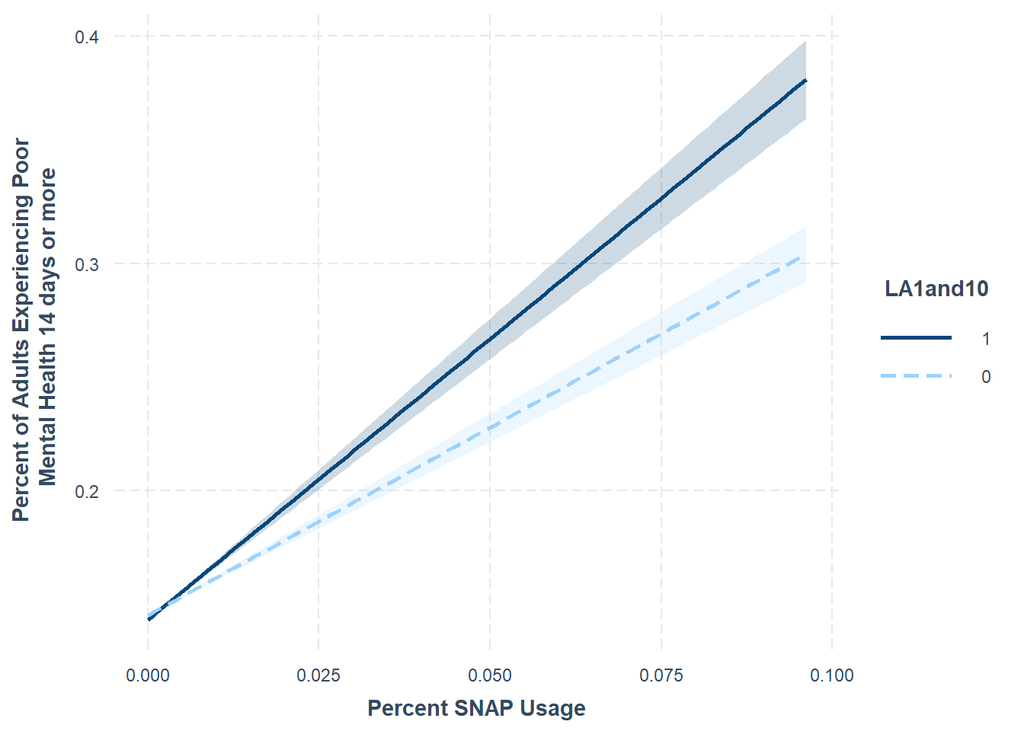

```r
interact_plot(interaction_SNAP_access_model, pred = pct_SNAP, modx = LA1and10,
              interval = TRUE) +
  scale_x_continuous(name = "Percent SNAP Usage") +
  scale_y_continuous(name = "Percent of Adults Experiencing Poor\n Mental Health 14 days or more")
```

## Final Model

```r
export_summs(full_model, scaled_MedIncome_model_log, interaction_SNAP_access_model,
             error_format = "(p = {p.value})",
             error_pos = "same",
             model.names = c("Initial",
                             "Median Income Logged",
                             "Median Income Logged and SNAP:Food Access Interaction"),
             coefs = coeff_names)
```

|  | Initial | Median Income Logged | Median Income Logged and SNAP:Food Access Interaction |
| --- | --- | --- | --- |
| Constant | 0.21 *** (p = 0.00) | 0.11 *** (p = 0.00) | 0.11 *** (p = 0.00) |
| SNAP Utilization | 0.02 *** (p = 0.00) | 1.83 *** (p = 0.00) | 1.65 *** (p = 0.00) |
| Poverty Rate | 0.00 *** (p = 0.00) | 0.12 *** (p = 0.00) | 0.12 *** (p = 0.00) |
| Median Age | -0.00 *** (p = 0.00) | -0.01 *** (p = 0.00) | -0.01 *** (p = 0.00) |
| Median Income | -0.00 *** (p = 0.00) |  |  |
| Doubling Median Income |  | -0.02 *** (p = 0.00) | -0.02 *** (p = 0.00) |
| % Units with Children | 0.02 *** (p = 0.00) | 2.39 *** (p = 0.00) | 2.43 *** (p = 0.00) |
| % White | -0.06 *** (p = 0.00) | -7.50 *** (p = 0.00) | -7.69 *** (p = 0.00) |
| % Black | 0.03 *** (p = 0.00) | 3.21 *** (p = 0.00) | 3.33 *** (p = 0.00) |
| % AI | 0.03 *** (p = 0.00) | 2.71 *** (p = 0.00) | 2.82 *** (p = 0.00) |
| % Asian | 0.06 *** (p = 0.00) | 5.81 *** (p = 0.00) | 5.86 *** (p = 0.00) |
| % NH | -0.02 ** (p = 0.00) | -2.52 *** (p = 0.00) | -2.41 *** (p = 0.00) |
| % Two Plus Races | -0.03 *** (p = 0.00) | -2.32 *** (p = 0.00) | -2.17 ** (p = 0.00) |
| Access to Food (1 Mile Urban and 10 Miles Rural) | -0.00 *** (p = 0.00) | -0.00 *** (p = 0.00) | -0.00 *** (p = 0.00) |
| N | 71990 | 71990 | 71990 |
| R2 | 0.84 | 0.85 | 0.85 |
| *** p < 0.001; ** p < 0.01; * p < 0.05. |  |  |  |

Adding the interaction coefficients described above to the regression analysis did not change the model fit compared to the model with the log of median income. The model of logged median income and the interaction coefficient for percent SNAP usage and food access is our preferred model because it is among the models with the best fit (R-squared value of 0.85) and it leads to more questions for further research. What other factors are leading to the difference in mental health as correlated with SNAP usage when comparing areas of high food access to areas of low food access?

# References

Ahern, Melissa, Brown, Cheryl, Dukas, Stephen. “A National Study of the Association Between Food Environments and County-Level Health Outcomes.” The Journal of Rural Health 27, no. 4 (2011): 367-379. doi: https://doi.org/10.1111/j.1748-0361.2011.00378.x

Centers for Disease Control and Prevention, “Census Tract Level State Maps of the Modified Retail Food Environment Index (mRFEI)” https://www.cdc.gov/obesity/downloads/census-tract-level-state-maps-mrfei_TAG508.pdf

Centers for Disease Control and Prevention, “PLACES: Local Data for Better Health, Census Tract Data 2020 release”. https://chronicdata.cdc.gov/500-Cities-Places/PLACES-Local-Data-for-Better-Health-Census-Tract-D/cwsq-ngmh

Jones, Andrew D.“Food Insecurity and Mental Health Status: A Global Analysis of 149 Countries.” American Journal of Preventative Medicine 53, no. 2 (2017): 264-273. doi: https://doi.org/10.1016/j.amepre.2017.04.008

Kaiser ML, Dionne J, Carr JK. “Predictors of Diet-Related Health Outcomes in Food-Secure and Food-Insecure Communities.” Soc Work Public Health 34, no.3 (2019):214-229. doi: 10.1080/19371918.2019.1575313. Epub 2019 Feb 15. PMID: 30767652.

Seligman, Hilary K., and Dean Schillinger. “Hunger and Socioeconomic Disparities in Chronic Disease.” The New England Journal of Medicine 363, no. 1 (2010): 6-9.

United States Census Bureau. American Community Survey, 5-year estimates. 2019.

United States Census Bureau. 2010.

United States Department of Agriculture. “Food Access Research Atlas”. 2019. “https://www.ers.usda.gov/data-products/food-access-research-atlas/download-the-data/”